# ICAR prior implementation validation

**NOTE**: Stan version 2.36 or later is required to render this R Markdown.

This simulation study aims to evaluate the implementation of the ICAR prior and a derivative of the BYM2 in Stan using the following criteria:

- How well can they recover the true parameter values
- Whether they outperform a control model that assumes spatial independence

All the simulation code and models assume that the neighborhood graph is fully connected. Revision is likely necessary in the future to handle graphs with multiple components.

## Data simulation

Our goal is to simulate data that contain a **geographic random effect with spatial autocorrelation**, i.e., nearby areas tend to have similar values. The Intrinsic Conditional Autoregressive (ICAR) prior encodes this idea by penalizing differences across adjacent areas. Let $A$ be the (binary) adjacency matrix of the areal units, $D=\mathrm{diag}(A\mathbf{1})$ the degree matrix, and $L=D-A$ the graph Laplacian. The ICAR prior (improper) has density
$$\log p(\boldsymbol\phi)\ \propto\ -\tfrac{1}{2}\sum_{(i,j)\in
E}(\phi_i-\phi_j)^2
\ =\ -\tfrac{1}{2}\,\boldsymbol\phi^\top L\,\boldsymbol\phi,$$
so fields with large neighbor-to-neighbor differences are unlikely, and smoother fields are preferred.

### Sample the ICAR component

**ICAR via the Laplacian eigenbasis.** The ICAR prior is singular: adding a constant to all $\phi_i$ leaves the penalty unchanged. Algebraically, the Laplacian $L$ is symmetric positive semidefinite with at least one zero eigenvalue; its nullspace is spanned by the constant vector $\mathbf{1}$ on each connected component. The code exploits this structure to draw an ICAR field:

1. **Diagonalize the Laplacian.** Compute $L = U\,\Lambda\,U^\top$, where $U$ is orthonormal and $\Lambda=\mathrm{diag}(\lambda_1,\ldots,\lambda_K)$ are the eigenvalues with $\lambda_1=0$ for a connected graph (more zeros if there are multiple components).
2. **Remove the nullspace.** Drop the eigenvectors associated with zero eigenvalues. Denote the remaining eigenvectors by $U_+$ and their eigenvalues by $\Lambda_+$ (all strictly positive).
3. **Sample in the positive-eigenvalue subspace.** Draw $\mathbf{z}\sim\mathcal{N}(\mathbf{0}, I)$ and set
   $$\boldsymbol{\phi}
   \;=\;
   U_{+}\,\Lambda_{+}^{-\alpha/2}\,\mathbf{z}.$$
   With $\alpha=1$ this matches the ICAR precision $L$ (i.e., $\boldsymbol\phi$ has covariance proportional to the Moore–Penrose inverse $L^+$). Choosing $\alpha>1$ is a **simulation-only smoothness knob** that further downweights high-frequency (wiggly) eigenmodes, creating broader, smoother patches; $\alpha=1$ recovers the standard ICAR spectrum.
4. **Impose identifiability (sum-to-zero).** Because the constant mode was removed, $\sum_i\phi_i=0$ holds automatically for a single connected component (for multiple components, ensure zero-sum **within each component**). This mirrors Stan’s `sum_to_zero_vector`, which makes the intercept identifiable.
5. **Normalize and scale.** For convenience, standardize $\boldsymbol\phi$ to unit standard deviation and then introduce a magnitude parameter in the linear predictor,
   $$\mathbf{a}_{\text{zip}} \;=\; \lambda_{\text{zip}}\,\boldsymbol{\phi},$$
   so that $\lambda_{\text{zip}}$ directly controls the strength of the spatial effect while $\boldsymbol{\phi}$ controls its **shape**.

I validated the sampled fields using standard measures of spatial autocorrelation:

- **Moran’s I**: values closer to 1 indicate strong positive spatial autocorrelation (neighbors tend to be similar); values near 0 suggest randomness; negative values indicate dispersion.
- **Geary’s C**: values closer to 0 indicate strong positive spatial autocorrelation; values around 1 suggest little to no autocorrelation; values >1 indicate negative autocorrelation.

I also visualize the sampled ICAR field as a heatmap on the lattice. Large, contiguous color patches and smooth gradients highlight the local smoothness induced by the ICAR prior.

```
Moran's I: 0.597302132860522
```

```
Geary's C: 0.351508174568192
```

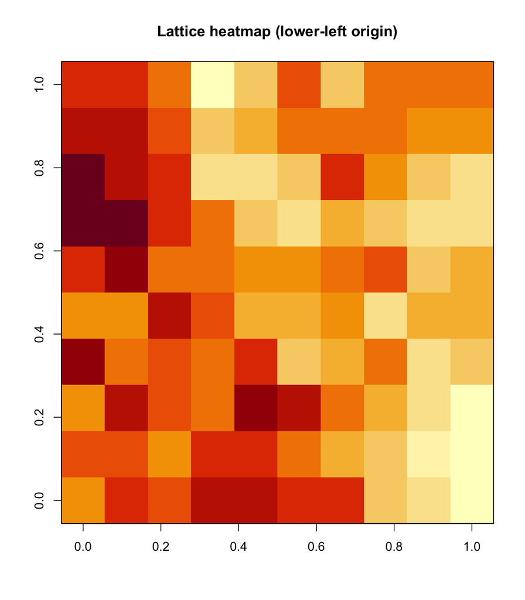

### Build a linear predictor and simulate data

The data simulation mirrors the Stan model structure used for fitting. Each observation $n=1,\dots,N$ has a binomial outcome
$$y_n \sim \mathrm{Binomial}\!\left(n_n,\; p_n\right),\qquad
\text{with}\;\; \mathrm{logit}(p_n)=\eta_n.$$
The linear predictor $\eta_n$ combines fixed effects and several varying effects:
$$\eta_n
= \beta_0 \;+\; \mathbf{x}_n^\top\boldsymbol\beta
\;+\; a^{(\mathrm{race})}_{J_{\mathrm{race}}[n]}
\;+\; a^{(\mathrm{age}) }_{J_{\mathrm{age}} [n]}
\;+\; a^{(\mathrm{time})}_{J_{\mathrm{time}}[n]}
\;+\; a^{(\mathrm{zip}) }_{J_{\mathrm{zip}} [n]}.$$
Here $\beta_0$ is the global intercept and $\mathbf{x}_n\in\mathbb{R}^K$ is a vector of observed covariates; $\boldsymbol\beta$ are the corresponding coefficients. The indices $J_{\mathrm{race}}[n]$, $J_{\mathrm{age}}[n]$, $J_{\mathrm{time}}[n]$, and $J_{\mathrm{zip}}[n]$ select the group-level effect for observation $n$.

For the non-spatial groups, the simulator uses independent Gaussian intercepts written in **non-centered** form:
$$\begin{aligned}
\mathbf{a}^{(\mathrm{race})} &=
\lambda_{\mathrm{race}}\;\mathbf{z}^{(\mathrm{race})}, \quad
&&\mathbf{z}^{(\mathrm{race})}\sim \mathcal{N}(\mathbf 0,
I_{N_{\mathrm{race}}}),\\
\mathbf{a}^{(\mathrm{age})} &=
\lambda_{\mathrm{age}}\;\,\mathbf{z}^{(\mathrm{age})}, \quad
&&\mathbf{z}^{(\mathrm{age})}\sim \mathcal{N}(\mathbf 0,
I_{N_{\mathrm{age}}}),\\
\mathbf{a}^{(\mathrm{time})} &=
\lambda_{\mathrm{time}}\;\mathbf{z}^{(\mathrm{time})}, \quad
&&\mathbf{z}^{(\mathrm{time})}\sim \mathcal{N}(\mathbf 0,
I_{N_{\mathrm{time}}}),
\end{aligned}$$
with scale hyperparameters $\lambda_{\bullet}\ge 0$. For the spatial effect over ZIP codes, the simulator uses an ICAR field (sum-to-zero) and the same scaling pattern:
$$\mathbf{a}^{(\mathrm{zip})} = \lambda_{\mathrm{zip}}\,\boldsymbol\phi,
\quad \boldsymbol\phi \sim \text{ICAR}(L)\ \text{ with }
\mathbf{1}^\top\boldsymbol\phi=0,$$
where $L$ is the graph Laplacian built from the ZIP adjacency. In the simulator, $\boldsymbol\phi$ is sampled in the Laplacian eigenbasis (dropping the zero-eigenvalue mode) and optionally normalized to unit SD; in Stan this corresponds to `sum_to_zero_vector` with an `icar_normal_lpdf` prior.

## Model fitting and comparison

I used leave-one-out cross-validation to compare the models with an ICAR and BYM2 component against the control model with independent effects for ZIP code. The two models with spatial prior consistently outperforms their counterpart but also are comparable. This is expected as the simulator is based on the model with the ICAR component and the BYM2 derivative approaches ICAR as $\rho$ is near 1.

### Model with no spatial prior

```
data {
  int<lower=1> N;
  int<lower=0> K;
  matrix[N, K] X;

  array[N] int y;
  array[N] int n_sample;

  int<lower=1> N_race;
  array[N] int<lower=1, upper=N_race> J_race;

  int<lower=1> N_age;
  array[N] int<lower=1, upper=N_age> J_age;

  int<lower=1> N_time;
  array[N] int<lower=1, upper=N_time> J_time;

  int<lower=1> N_zip;
  array[N] int<lower=1, upper=N_zip> J_zip;
}

parameters {
  real intercept;
  vector[K] beta;
  real<lower=0> lambda_race;
  vector[N_race] z_race;
  real<lower=0> lambda_age;
  vector[N_age] z_age;
  real<lower=0> lambda_time;
  vector[N_time] z_time;
  real<lower=0> lambda_zip;
  vector[N_zip] z_zip;
}

transformed parameters {
  vector[N_race] a_race = z_race * lambda_race;
  vector[N_age] a_age = z_age * lambda_age;
  vector[N_time] a_time = z_time * lambda_time;
  vector[N_zip] a_zip = z_zip * lambda_zip;
  vector<lower=0, upper=1>[N] p = inv_logit(intercept + X * beta + a_race[J_race] + a_age[J_age] + a_time[J_time] + a_zip[J_zip]);
}

model {
  y ~ binomial(n_sample, p);
  intercept ~ normal(0, 5);
  beta[1] ~ normal(0, 3);
  z_race ~ std_normal();
  z_age ~ std_normal();
  z_time ~ std_normal();
  z_zip ~ std_normal();
  lambda_race ~ normal(0, 3);
  lambda_age ~ normal(0, 3);
  lambda_time ~ normal(0, 3);
  lambda_zip ~ normal(0, 3);
}

generated quantities {
  vector[N] log_lik;
  for (n in 1:N) {
    log_lik[n] = binomial_lpmf(y[n] | n_sample[n], p[n]);
  }
}
```

### Model with ICAR prior

```
functions {
  real icar_normal_lpdf(vector phi, array[] int node1, array[] int node2) {
    return -0.5 * dot_self(phi[node1] - phi[node2]);
  }
}

data {
  int<lower=1> N;
  int<lower=0> K;
  matrix[N, K] X;

  array[N] int y;
  array[N] int n_sample;

  int<lower=1> N_race;
  array[N] int<lower=1, upper=N_race> J_race;

  int<lower=1> N_age;
  array[N] int<lower=1, upper=N_age> J_age;

  int<lower=1> N_time;
  array[N] int<lower=1, upper=N_time> J_time;

  int<lower=1> N_zip;
  array[N] int<lower=1, upper=N_zip> J_zip;

  int<lower=0> N_edges_zip;
  array[N_edges_zip] int<lower=1, upper=N_zip> node1_zip;
  array[N_edges_zip] int<lower=1, upper=N_zip> node2_zip;
}

parameters {
  real intercept;
  vector[K] beta;
  real<lower=0> lambda_race;
  vector[N_race] z_race;
  real<lower=0> lambda_age;
  vector[N_age] z_age;
  real<lower=0> lambda_time;
  vector[N_time] z_time;
```

[output cut: 21 more lines]

```
  z_age ~ std_normal();
  z_time ~ std_normal();
  z_zip ~ icar_normal(node1_zip, node2_zip);
  lambda_race ~ normal(0, 3);
  lambda_age ~ normal(0, 3);
  lambda_time ~ normal(0, 3);
  lambda_zip ~ std_normal();
}

generated quantities {
  vector[N] log_lik;
  for (n in 1:N) {
    log_lik[n] = binomial_lpmf(y[n] | n_sample[n], p[n]);
  }
}
```

### Model with mixture of an ICAR term and spatially independent heterogeniety (BYM2)

```
functions {
  real icar_normal_lpdf(vector phi, array[] int node1, array[] int node2) {
    return -0.5 * dot_self(phi[node1] - phi[node2]);
  }
}

data {
  int<lower=1> N;
  int<lower=0> K;
  matrix[N, K] X;

  array[N] int y;
  array[N] int n_sample;

  int<lower=1> N_race;
  array[N] int<lower=1, upper=N_race> J_race;

  int<lower=1> N_age;
  array[N] int<lower=1, upper=N_age> J_age;

  int<lower=1> N_time;
  array[N] int<lower=1, upper=N_time> J_time;

  int<lower=1> N_zip;
  array[N] int<lower=1, upper=N_zip> J_zip;

  int<lower=0> N_edges_zip;
  array[N_edges_zip] int<lower=1, upper=N_zip> node1_zip;
  array[N_edges_zip] int<lower=1, upper=N_zip> node2_zip;
  real<lower=0> scale_factor;
}

parameters {
  real intercept;
  vector[K] beta;
  real<lower=0> lambda_race;
  vector[N_race] z_race;
  real<lower=0> lambda_age;
  vector[N_age] z_age;
  real<lower=0> lambda_time;
```

[output cut: 27 more lines]

```
  theta_zip ~ std_normal();
  phi_zip ~ icar_normal(node1_zip, node2_zip);
  rho_zip ~ beta(0.5, 0.5);
  lambda_race ~ normal(0, 3);
  lambda_age ~ normal(0, 3);
  lambda_time ~ normal(0, 3);
  lambda_zip ~ std_normal();
}

generated quantities {
  vector[N] log_lik;
  for (n in 1:N) {
    log_lik[n] = binomial_lpmf(y[n] | n_sample[n], p[n]);
  }
}
```

```
$intercept
[1] 0

$beta
[1] -0.2

$lambda_race
[1] 0.2

$lambda_age
[1] 0.15

$lambda_time
[1] 0.3

$lambda_zip
[1] 1.8
```

```
BYM2 model sampling summary
```

```
# A tibble: 8 × 8
  variable          mean      sd         q5       q95  rhat ess_bulk ess_tail
  <chr>            <dbl>   <dbl>      <dbl>     <dbl> <dbl>    <dbl>    <dbl>
1 lp__        -2909.     12.7    -2930.     -2889.     1.00    1030.    1666.
2 intercept      -0.0213  0.435     -0.701      0.635  1.00    1640.    1652.
3 beta[1]        -0.291   0.0513    -0.375     -0.205  1.00    5440.    3035.
4 lambda_race     0.549   0.446      0.190      1.38   1.00    1669.    1699.
5 lambda_age      0.211   0.170      0.0423     0.502  1.00    1592.    1521.
6 lambda_time     0.548   0.275      0.269      1.08   1.00    1525.    1658.
7 lambda_zip      1.59    0.139      1.37       1.83   1.00     964.    1452.
8 rho_zip         0.938   0.0753     0.781      1.00   1.02     169.     318.
```

```
ICAR model sampling summary
```

```
# A tibble: 7 × 8
  variable           mean      sd         q5       q95  rhat ess_bulk ess_tail
  <chr>             <dbl>   <dbl>      <dbl>     <dbl> <dbl>    <dbl>    <dbl>
1 lp__        -2858.      10.5    -2876.     -2842.     1.00     602.    1328.
2 intercept      -0.00734  0.443     -0.695      0.702  1.01     628.     450.
3 beta[1]        -0.291    0.0493    -0.371     -0.208  1.00    2856.    2926.
4 lambda_race     0.566    0.460      0.189      1.48   1.01     798.     608.
5 lambda_age      0.202    0.163      0.0365     0.490  1.01     736.     499.
6 lambda_time     0.544    0.279      0.267      1.04   1.00     935.    1313.
7 lambda_zip      2.01     0.161      1.76       2.28   1.01     491.     958.
```

```
IID model sampling summary
```

```
# A tibble: 7 × 8
  variable          mean      sd         q5       q95  rhat ess_bulk ess_tail
  <chr>            <dbl>   <dbl>      <dbl>     <dbl> <dbl>    <dbl>    <dbl>
1 lp__        -2856.     10.9    -2875.     -2838.     1.01     521.    1112.
2 intercept      -0.0161  0.487     -0.774      0.762  1.00     786.     938.
3 beta[1]        -0.276   0.0512    -0.361     -0.191  1.00    2626.    1573.
4 lambda_race     0.576   0.447      0.192      1.41   1.00    1194.    1201.
5 lambda_age      0.237   0.218      0.0505     0.582  1.00     872.     861.
6 lambda_time     0.538   0.269      0.264      1.05   1.00    1255.    1684.
7 lambda_zip      1.81    0.147      1.59       2.06   1.01     388.    1076.
```

```
     elpd_diff se_diff
bym2  0.0       0.0
icar -0.5       1.1
iid  -7.3       3.0
```

### Sanity check: ICAR prior with $\tau$

```
functions {
  real icar_normal_lpdf(vector phi, real tau, array[] int node1, array[] int node2) {
    return -0.5 * tau * dot_self(phi[node1] - phi[node2]);
  }
}

data {
  int<lower=1> N;
  int<lower=0> K;
  matrix[N, K] X;

  array[N] int y;
  array[N] int n_sample;

  int<lower=1> N_race;
  array[N] int<lower=1, upper=N_race> J_race;

  int<lower=1> N_age;
  array[N] int<lower=1, upper=N_age> J_age;

  int<lower=1> N_time;
  array[N] int<lower=1, upper=N_time> J_time;

  int<lower=1> N_zip;
  array[N] int<lower=1, upper=N_zip> J_zip;

  int<lower=0> N_edges_zip;
  array[N_edges_zip] int<lower=1, upper=N_zip> node1_zip;
  array[N_edges_zip] int<lower=1, upper=N_zip> node2_zip;
}

parameters {
  real intercept;
  vector[K] beta;
  real<lower=0> lambda_race;
  vector[N_race] z_race;
  real<lower=0> lambda_age;
  vector[N_age] z_age;
  real<lower=0> lambda_time;
  vector[N_time] z_time;
```

[output cut: 23 more lines]

```
  z_time ~ std_normal();
  z_zip ~ icar_normal(tau_zip, node1_zip, node2_zip);
  lambda_race ~ normal(0, 3);
  lambda_age ~ normal(0, 3);
  lambda_time ~ normal(0, 3);
  lambda_zip ~ normal(0, 3);
  tau_zip ~ gamma(2, 2);
}

generated quantities {
  vector[N] log_lik;
  for (n in 1:N) {
    log_lik[n] = binomial_lpmf(y[n] | n_sample[n], p[n]);
  }
}
```

```r
out <- fit_and_compare(
  data = sim$stan_data,
  stan_models = c(
    paste0(stan_dir, "icar_w_tau.stan")
  ),
  model_labels = c("icar_w_tau"),
  max_treedepth = 15
)
```

```
ICAR model with tau sampling summary
```

```
# A tibble: 7 × 8
  variable         mean       sd        q5       q95  rhat ess_bulk ess_tail
  <chr>           <dbl>    <dbl>     <dbl>     <dbl> <dbl>    <dbl>    <dbl>
1 lp__        -3.02e+ 3 7.76e+ 0 -3.03e+ 3 -3.01e+ 3  1.04    63.1     119.
2 intercept    2.38e- 2 4.42e- 1 -6.46e- 1  6.92e- 1  1.00  3061.     3774.
3 beta[1]     -2.86e- 1 4.69e- 2 -3.62e- 1 -2.08e- 1  1.11    25.3      80.0
4 lambda_race  5.82e- 1 4.56e- 1  2.03e- 1  1.40e+ 0  1.01   655.     2135.
5 lambda_age   2.21e- 1 1.69e- 1  6.35e- 2  5.12e- 1  1.03   158.     1204.
6 lambda_time  4.93e- 1 2.49e- 1  2.42e- 1  9.67e- 1  1.01  1091.     2432.
7 lambda_zip   8.87e-19 4.22e-19  4.84e-19  1.85e-18  1.85     5.75     NA
```